# MA-Aufgaben14

```python
import numpy as np
import matplotlib.pyplot as plt
import matplotlib.cm as cm

import warnings
warnings.filterwarnings(action='ignore')
```

### Integralsätze

1. Berechnen Sie den Fluss durch die Oberfläche eines Würfels ($0 \le x \le 1, 0 \le y \le 1, 0 \le z \le 1$) für das Vektorfeld $$\vec{\mathbf{F}} = \left(\begin{array}{c} xy \\ y^2 \\ xz \end{array}\right)$$ unter Anwendung des Integralsatzes von Gauß.
2. Berechnen Sie den Wirbelfluss des Vektorfeld $$\vec{\mathbf{F}}(x,y,z) = \left( \begin{array}{c} -y \\ 2x \\ z \end{array} \right ) $$ für die Halbkugel $x^2 + y^2 + z^2 = 9$ mit $z \ge 0$ unter Verwendung des Integralsatzes von Stokes.
3. Das elektrische Feld in der Umgebung einer homogen geladenen Kugel (Radius $R$) lässt sich durch die elektrische Feldstärke $$\mathbf{\vec{E}}_A = \dfrac{k}{r^2} \mathbf{\vec{e}}_r$$ beschreiben ($k>0$, $r$ - Abstand vom Kugelmittelpunkt, $r \ge R$, $\mathbf{\vec{E}}_A$ - elektr. Feldstärke außerhalb der Kugel). Die konstante Ladungsdichte $\varrho_{el}$ im Inneren der Kugel ergibt sich aus einer der Maxwellschen Gleichung als $$\varrho_{el} = \epsilon_0 \mathrm{div}\left(\mathbf{\vec{E}}_I\right)$$ mit $\epsilon_0$ als elektrische Feldkonstante und $\mathbf{\vec{E}}_I$ als unbekannte Feldstärke im Inneren der Kugel. Bestimme die Ladung und die Ladungsdichte der Kugel.

#### Lösung

*1)*

- Würfel hat eine geschlossene Oberfläche, daher ist Integralsatz von Gauss anwendbar
- Integralsatz von Gauss: $\oint_{(A)} \vec{\mathbf{F}}^{\scriptscriptstyle \mathrm{T}} \mathrm{d}\vec{\mathbf{A}} = \iiint_{(V)} \mathrm{div}\vec{\mathbf{F}} \mathrm{d}V$
- *in der Ebene*: $\oint_{(C)} \vec{\mathbf{F}}^{\scriptscriptstyle \mathrm{T}} \vec{\mathbf{N}} \mathrm{d}s = \iint_{(A)} \mathrm{div}\vec{\mathbf{F}} \mathrm{d}A$
- Koordinatensystem: kartesische Koordinaten
- Berechnung der Divergenz: $\mathrm{div}\vec{\mathbf{F}} = y + 2y + x = 3y + x$
- Berechnung des Volumenintegrals: $\int_{x=0}^{1} \int_{y=0}^{1} \int_{z=0}^1 \left[x + 3y\right] \mathrm{d}{z}\mathrm{d}{y}\mathrm{d}{x} = 2$

*2)*

- Wirbelfluss: Fluss von $\mathrm{rot}\vec{\mathbf{F}}$ durch eine Fläche $A$
- Integralsatz von Stoke: $\oint_{(C)} \vec{\mathbf{F}}^{\scriptscriptstyle \mathrm{T}} \mathrm{d}\vec{\mathbf{r}} = \iint_{(A)} \left(\mathrm{rot}\vec{\mathbf{F}}\right)^{\scriptscriptstyle \mathrm{T}} \mathrm{d}A$
- Randkurve $C$: Mittelpunktskreis mit Radius 3 in der x-y-Ebene
- Berechnung des Integranden (noch in kartesischen Koordinaten): $ \mathrm{d}\vec{\mathbf{r}} = \left[\mathrm{d}x , \mathrm{d}y\right]^{\scriptscriptstyle \mathrm{T}}, \; \vec{\mathbf{F}}^{\scriptscriptstyle \mathrm{T}} \mathrm{d}\vec{\mathbf{r}} = -y\mathrm{d}x + 2x\mathrm{d}y$
- Umrechnung in Polarkoordinaten: $ x = r \cos(\varphi) = 3 \cos(\varphi), \; \mathrm{d}x = \dfrac{\partial x}{\partial r}\mathrm{d}r + \dfrac{\partial x}{\partial \varphi}\mathrm{d}\varphi = - 3\sin(\varphi)\mathrm{d}\varphi$ $ y = r \sin(\varphi) = 3 \sin(\varphi), \; \mathrm{d}y = \dfrac{\partial y}{\partial r}\mathrm{d}r + \dfrac{\partial y}{\partial \varphi}\mathrm{d}\varphi = 3\cos(\varphi)\mathrm{d}\varphi$
- Einsetzen und Bestimmung des Integrals:

$\oint_{(C)} \vec{\mathbf{F}}^{\scriptscriptstyle \mathrm{T}} \mathrm{d}\vec{\mathbf{r}} = \int_{0}^{2\pi} \left[9\sin^2(\varphi) + 18 \cos^2(\varphi)\right]\mathrm{d}\varphi $

$\qquad = 9\int_{0}^{2\pi} \left[\sin^2(\varphi) + 2 \cos^2(\varphi)\right]\mathrm{d}\varphi = 9\int_{0}^{2\pi} \left[\left(1 - \cos^2(\varphi)\right) + 2 \cos^2(\varphi)\right]\mathrm{d}\varphi$

$\qquad = 9\int_{0}^{2\pi} \left[1 + \cos^2(\varphi)\right]\mathrm{d}\varphi = 9 \left[\varphi|_0^{2\pi} + \left(\frac{\varphi}{2} + \frac{\sin(2\varphi)}{4}\right)|_{0}^{2\pi}\right] = 27 \pi$

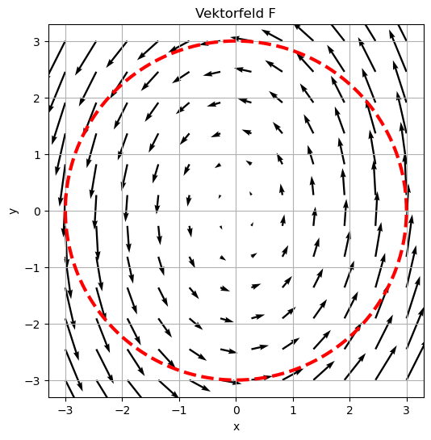

```python
fig = plt.figure(figsize=(6,6))

x = np.linspace(-3, 3, 12)
y = np.linspace(-3, 3, 12)
X,Y = np.meshgrid(x,y)

r = 3
phi = np.linspace(0, 2*np.pi, 181)

ax1 = fig.add_subplot(111)
ax1.quiver(X, Y, -Y, 2*X, scale_units='xy', angles='xy', scale=8)
ax1.plot(r*np.cos(phi), r*np.sin(phi), color='red', linestyle='--', linewidth=3)
ax1.grid()
ax1.set_xlabel('x')
ax1.set_ylabel('y')
ax1.set_title('Vektorfeld F')

plt.show()
```

*3*)

- Ladung der Kugel: $Q = \int_{(V)} \mathrm{d}Q = \int_{(V)} \varrho_{el} \mathrm{d}V$
- Einsetzen der Maxwellschen Gleichung: $Q = \epsilon_0 \int_{(V)} \mathrm{div}\left(\mathbf{\vec{E}}_I\right) \mathrm{d}V$
- Integralsatz von Gauß an der Kugeloberfläche $r = R$: $\int_{(V)} \mathrm{div}\left(\mathbf{\vec{E}}_I\right) \mathrm{d}V = \oint_{(A)} \mathbf{\vec{E}}_A^{\scriptscriptstyle \mathrm{T}} \mathbf{\vec{N}} \mathrm{d}A = \dfrac{k}{R^2}\oint_{(A)}\mathrm{d}A$
- Oberfläche ist die einer Kugel: $\oint_{(A)}\mathrm{d}A = 4 \pi R^2$
- Ladung in der Kugel: $Q = 4 \pi \epsilon_0 k$
- Ladungsdichte in der Kugel: $\varrho_{el} = \dfrac{4 \pi \epsilon_0 k}{\frac{4}{3} \pi R^3} = \dfrac{3 \epsilon_0 k}{R^3}$